# PUBG-data-analysis

Naiqing Cai, Hao Pan, Qintao Ying, Yuchen Zeng

12/8/2019

# Introduction

The main goal of analyzing the PUBG data is to provide some advice for PUBG players to get a higher rank in each match and detect the cheaters. We will analyze the properties, advantages of different kinds of weapons, the relationship between walking, driving speed and the team rank. In addition, we will analyze death records that survive for less than 4 minutes to provide players with some suggestions to avoid a bad gaming experience.

Our dataset consists of two zips: aggregate and deaths. The CSV files in deaths folder record every death that occurred in a total of 720 thousand matches. Each file provides the information of victim and killer such as their name, position, weapon. Each player’s statistics in all matches are summerized in CSV files in the aggregate folder. The files contain match id, team placement, damage, etc.

# Data Analysis

```
##              random.forest    knn adaboost logistic.regression
## party size 1        96.84% 96.81%   96.45%              77.32%
## party size 2        94.32% 94.95%   90.42%              69.48%
## party size 4        92.63% 93.09%   90.26%              75.15%
```

# Conclusion

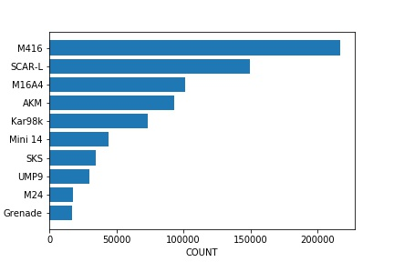

- The most popular weapon used by the winner is M416, followed by SCAR-L, M16A4, AKM, according to figure above. The most popular sniper rifle is Kar98k. Rifles are more popular than sniper rifles.

[figure not shown]

[figure not shown]

- For erangel map, the areas with the highest mortality rates are Roznok and Sosnovka Military Base, followed by other large towns. As for miramar map, Pecado and San Martin have the highest mortality rate. Novices who want to survive longer should avoid these areas.
- Generally speaking, high rank players tend to kill more players, cause more damage, walk and drive faster to other players than low rank players. This is to say, to achieve higher rank, players are encouraged to move and shoot instead of staying somewhere and waiting for other players killing each other. For different party size, the key aspects that affect the ranking most are different. For party size 1 players, it is player kills and player damage that count. For party size 2 players, average driving speed and player damage are most important. For party size 4 players, players should focus more on two average moving speed.